# ExtraaLearn Project

## Context

The EdTech industry has been surging in the past decade immensely, and according to a forecast, the Online Education market would be worth $286.62bn by 2023 with a compound annual growth rate (CAGR) of 10.26% from 2018 to 2023. The modern era of online education has enforced a lot in its growth and expansion beyond any limit. Due to having many dominant features like ease of information sharing, personalized learning experience, transparency of assessment, etc, it is now preferable to traditional education.

In the present scenario due to the Covid-19, the online education sector has witnessed rapid growth and is attracting a lot of new customers. Due to this rapid growth, many new companies have emerged in this industry. With the availability and ease of use of digital marketing resources, companies can reach out to a wider audience with their offerings. The customers who show interest in these offerings are termed as leads. There are various sources of obtaining leads for Edtech companies, like

- The customer interacts with the marketing front on social media or other online platforms.
- The customer browses the website/app and downloads the brochure
- The customer connects through emails for more information.

The company then nurtures these leads and tries to convert them to paid customers. For this, the representative from the organization connects with the lead on call or through email to share further details.

## Objective

ExtraaLearn is an initial stage startup that offers programs on cutting-edge technologies to students and professionals to help them upskill/reskill. With a large number of leads being generated on a regular basis, one of the issues faced by ExtraaLearn is to identify which of the leads are more likely to convert so that they can allocate resources accordingly. You, as a data scientist at ExtraaLearn, have been provided the leads data to:

- Analyze and build an ML model to help identify which leads are more likely to convert to paid customers,
- Find the factors driving the lead conversion process
- Create a profile of the leads which are likely to convert

## Data Description

The data contains the different attributes of leads and their interaction details with ExtraaLearn. The detailed data dictionary is given below.

**Data Dictionary**

- ID: ID of the lead
- age: Age of the lead
- current_occupation: Current occupation of the lead. Values include 'Professional','Unemployed',and 'Student'
- first_interaction: How did the lead first interacted with ExtraaLearn. Values include 'Website', 'Mobile App'
- profile_completed: What percentage of profile has been filled by the lead on the website/mobile app. Values include Low - (0-50%), Medium - (50-75%), High (75-100%)
- website_visits: How many times has a lead visited the website
- time_spent_on_website: Total time spent on the website
- page_views_per_visit: Average number of pages on the website viewed during the visits.
- last_activity: Last interaction between the lead and ExtraaLearn.
  - Email Activity: Seeking for details about program through email, Representative shared information with lead like brochure of program , etc
  - Phone Activity: Had a Phone Conversation with representative, Had conversation over SMS with representative, etc
  - Website Activity: Interacted on live chat with representative, Updated profile on website, etc
- print_media_type1: Flag indicating whether the lead had seen the ad of ExtraaLearn in the Newspaper.
- print_media_type2: Flag indicating whether the lead had seen the ad of ExtraaLearn in the Magazine.
- digital_media: Flag indicating whether the lead had seen the ad of ExtraaLearn on the digital platforms.
- educational_channels: Flag indicating whether the lead had heard about ExtraaLearn in the education channels like online forums, discussion threads, educational websites, etc.
- referral: Flag indicating whether the lead had heard about ExtraaLearn through reference.
- status: Flag indicating whether the lead was converted to a paid customer or not.

## Importing necessary libraries and data

```python
# Standard libraries
import pandas as pd
import numpy as np

# Data plotting libraries
import matplotlib.pyplot as plt
import seaborn as sns

# Importing the Machine Learning libraries
from sklearn.tree import DecisionTreeClassifier
from sklearn import tree
from sklearn.ensemble import RandomForestClassifier

# Importing the other functions
from sklearn.model_selection import train_test_split, GridSearchCV
from sklearn.metrics import confusion_matrix,classification_report

# ignore warnings
import warnings;
warnings.filterwarnings('ignore')
```

Making sure the data can be efficiently loaded:

```python
# Mount drive
from google.colab import drive
drive.mount('/content/drive')
# Change to the correct directory
import os
os.chdir("/content/drive/MyDrive/Week8/Project Assessment")
```

## Data Overview

- Observations
- Sanity checks

We first read in the data

```python
# Read in the data using read_csv from the Pandas library
data=pd.read_csv('ExtraaLearn.csv')
```

We create a copy for the next steps:

```python
df = data.copy()
```

We check the data using tail() and head()

```python
df.head()
```

|  | ID | age | current_occupation | first_interaction | profile_completed | website_visits | time_spent_on_website | page_views_per_visit | last_activity | print_media_type1 | print_media_type2 | digital_media | educational_channels | referral | status |
| --- | --- | --- | --- | --- | --- | --- | --- | --- | --- | --- | --- | --- | --- | --- | --- |
| 0 | EXT001 | 57 | Unemployed | Website | High | 7 | 1639 | 1.861 | Website Activity | Yes | No | Yes | No | No | 1 |
| 1 | EXT002 | 56 | Professional | Mobile App | Medium | 2 | 83 | 0.320 | Website Activity | No | No | No | Yes | No | 0 |
| 2 | EXT003 | 52 | Professional | Website | Medium | 3 | 330 | 0.074 | Website Activity | No | No | Yes | No | No | 0 |
| 3 | EXT004 | 53 | Unemployed | Website | High | 4 | 464 | 2.057 | Website Activity | No | No | No | No | No | 1 |
| 4 | EXT005 | 23 | Student | Website | High | 4 | 600 | 16.914 | Email Activity | No | No | No | No | No | 0 |

```python
df.tail()
```

|  | ID | age | current_occupation | first_interaction | profile_completed | website_visits | time_spent_on_website | page_views_per_visit | last_activity | print_media_type1 | print_media_type2 | digital_media | educational_channels | referral | status |
| --- | --- | --- | --- | --- | --- | --- | --- | --- | --- | --- | --- | --- | --- | --- | --- |
| 4607 | EXT4608 | 35 | Unemployed | Mobile App | Medium | 15 | 360 | 2.170 | Phone Activity | No | No | No | Yes | No | 0 |
| 4608 | EXT4609 | 55 | Professional | Mobile App | Medium | 8 | 2327 | 5.393 | Email Activity | No | No | No | No | No | 0 |
| 4609 | EXT4610 | 58 | Professional | Website | High | 2 | 212 | 2.692 | Email Activity | No | No | No | No | No | 1 |
| 4610 | EXT4611 | 57 | Professional | Mobile App | Medium | 1 | 154 | 3.879 | Website Activity | Yes | No | No | No | No | 0 |
| 4611 | EXT4612 | 55 | Professional | Website | Medium | 4 | 2290 | 2.075 | Phone Activity | No | No | No | No | No | 0 |

What is the shape of the dataset?

```python
df.shape
```

```
(4612, 15)
```

4612 rows and 15 columns. Further we will continue to check if there are missing entries.

## Exploratory Data Analysis (EDA)

- EDA is an important part of any project involving data.
- It is important to investigate and understand the data better before building a model with it.
- A few questions have been mentioned below which will help you approach the analysis in the right manner and generate insights from the data.
- A thorough analysis of the data, in addition to the questions mentioned below, should be done.

**Questions**

1. Leads will have different expectations from the outcome of the course and the current occupation may play a key role in getting them to participate in the program. Find out how current occupation affects lead status.
2. The company's first impression on the customer must have an impact. Do the first channels of interaction have an impact on the lead status?
3. The company uses multiple modes to interact with prospects. Which way of interaction works best?
4. The company gets leads from various channels such as print media, digital media, referrals, etc. Which of these channels have the highest lead conversion rate?
5. People browsing the website or mobile application are generally required to create a profile by sharing their personal data before they can access additional information.Does having more details about a prospect increase the chances of conversion?

## Data Preprocessing

- Missing value treatment (if needed)
- Feature engineering (if needed)
- Outlier detection and treatment (if needed)
- Preparing data for modeling
- Any other preprocessing steps (if needed)

```python
# We check the data types and see if there are any missing entries
df.info()
```

```
<class 'pandas.core.frame.DataFrame'>
RangeIndex: 4612 entries, 0 to 4611
Data columns (total 15 columns):
 #   Column                 Non-Null Count  Dtype
---  ------                 --------------  -----
 0   ID                     4612 non-null   object
 1   age                    4612 non-null   int64
 2   current_occupation     4612 non-null   object
 3   first_interaction      4612 non-null   object
 4   profile_completed      4612 non-null   object
 5   website_visits         4612 non-null   int64
 6   time_spent_on_website  4612 non-null   int64
 7   page_views_per_visit   4612 non-null   float64
 8   last_activity          4612 non-null   object
 9   print_media_type1      4612 non-null   object
 10  print_media_type2      4612 non-null   object
 11  digital_media          4612 non-null   object
 12  educational_channels   4612 non-null   object
 13  referral               4612 non-null   object
 14  status                 4612 non-null   int64
dtypes: float64(1), int64(4), object(10)
memory usage: 540.6+ KB
```

Observations:

- All columns have the same amount of entries (4612), which is also the amount of rows of this dataset. So there is no missing data.
- Only age, website visits, time spent on the website, page views per visit and the status are numerical. The other ones are objects and mostly categorical. However, many of those can be see as booleans as well (e.g. all the flags like digital_media or referral)

## EDA

- It is a good idea to explore the data once again after manipulating it.
- We check the statistics behind the numerical data

```python
# We use describe to check the distribution of the numerical data
df.describe().T
```

|  | count | mean | std | min | 25% | 50% | 75% | max |
| --- | --- | --- | --- | --- | --- | --- | --- | --- |
| age | 4612.0 | 46.201214 | 13.161454 | 18.0 | 36.00000 | 51.000 | 57.00000 | 63.000 |
| website_visits | 4612.0 | 3.566782 | 2.829134 | 0.0 | 2.00000 | 3.000 | 5.00000 | 30.000 |
| time_spent_on_website | 4612.0 | 724.011275 | 743.828683 | 0.0 | 148.75000 | 376.000 | 1336.75000 | 2537.000 |
| page_views_per_visit | 4612.0 | 3.026126 | 1.968125 | 0.0 | 2.07775 | 2.792 | 3.75625 | 18.434 |
| status | 4612.0 | 0.298569 | 0.457680 | 0.0 | 0.00000 | 0.000 | 1.00000 | 1.000 |

Observations:

- The age ranges from 18 to 63 old
- Most people do not spend a lot of time on the website, with an average of 3.5 visits. The maximum is 30 visits. Some people did not visit the website. This seems odd. These might be outliers or just people who connected over another medium e.g. social media, referral or phone.
- The average time spent on the website is 724 minutes, with a minimum of zero again (see above). The maximum is 2537 minutes.
- The average pages views per visit is 3, with a minimum of 0. The maximum is 18.4 views.
- The status is a flag feature and logically only had 0 or 1.

To check the categorical values in more depth, we will check their unique values for each.

```python
categorical_col = df.select_dtypes(exclude=['number']).columns.tolist()
```

We print for each of these columns the different unique values

```python
for col in categorical_col:
  print(data[col].value_counts())
  print("-" * 20)
```

```
ID
EXT001     1
EXT2884    1
EXT3080    1
EXT3079    1
EXT3078    1
          ..
EXT1537    1
EXT1536    1
EXT1535    1
EXT1534    1
EXT4612    1
Name: count, Length: 4612, dtype: int64
--------------------
current_occupation
Professional    2616
Unemployed      1441
Student          555
Name: count, dtype: int64
--------------------
first_interaction
Website       2542
Mobile App    2070
Name: count, dtype: int64
--------------------
profile_completed
High      2264
Medium    2241
Low        107
Name: count, dtype: int64
--------------------
last_activity
Email Activity      2278
Phone Activity      1234
Website Activity    1100
Name: count, dtype: int64
--------------------
print_media_type1
No     4115
Yes     497
Name: count, dtype: int64
--------------------
print_media_type2
No     4379
Yes     233
Name: count, dtype: int64
--------------------
digital_media
No     4085
Yes     527
Name: count, dtype: int64
--------------------
educational_channels
No     3907
Yes     705
Name: count, dtype: int64
--------------------
referral
No     4519
Yes      93
Name: count, dtype: int64
--------------------
```

Observations:

- The ID column does not say that much and will be later excluded for further analysis as it will not contribute to a model.
- Current occupation, first interaction, profile completed and last activity are pure categorical features.
- The remaining flags can also be encoded as numerical values, which can potentially make the further analysis easier when comparing with the other numerical values.

We make (only for the bi-variate analysis) some dummy columns of the flags with a numerical value (similar to the status column), which we will drop later again.

```python
df['print_media_type1_num'] = df['print_media_type1'].map({'Yes': 1, 'No': 0})
df['print_media_type2_num'] = df['print_media_type2'].map({'Yes': 1, 'No': 0})
df['digital_media_num'] = df['digital_media'].map({'Yes': 1, 'No': 0})
df['educational_channels_num'] = df['educational_channels'].map({'Yes': 1, 'No': 0})
df['referral_num'] = df['referral'].map({'Yes': 1, 'No': 0})
```

#### Drop the ID column

Check to see if there are any double IDs and drop the column from the further analysis.

```python
ID_count = df['ID'].value_counts()
(ID_count>1).any()
```

```
False
```

There are no double entries. We can drop this column.

```python
df = df.drop(['ID'], axis = 1)
```

#### Univariate analysis numerical

Before we start the univariate analysis, we make some functions to plot boxplots and histograms. In contrast with the previous assessment, we will plot the boxplot and histogram with a shared horizontal axis, to make the analysis easier

```python
def variable_name(input_string):
  """
  Maps input strings to their more readable counterpart.

  Args:
    input_string: The input string to be mapped.

  Returns:
    The more readable output string.
  """
  mapping = {'age': 'Age',
             'current_occupation': 'Current Occupation',
             'first_interaction': 'First Interaction',
             'profile_completed': 'Profile Completed',
             'website_visits': 'Website Visits',
             'time_spent_on_website': 'Time Spent on Website',
             'page_views_per_visit': 'Page Views per Visit',
             'last_activity': 'Last Activity',
             'print_media_type1': 'Newspaper',
             'print_media_type2': 'Magazine',
             'digital_media': 'Digital Plaform',
             'educational_channels': 'Educational Channel',
             'referral': 'Referral',
             'status': 'Status',
             }

  return mapping.get(input_string, input_string) # Default to input_string if not found
```

```python
def hist_box_plot(df: pd.DataFrame, num_var: str, x_label:str=None, graph_title:str=None):
  """
  Creates a boxplot with below it a histogram on the same horizontal axis for a numerical variable in a Pandas DataFrame.

  Args:
      df (pd.DataFrame): The Pandas DataFrame containing the data.
      num_var (str): The name of the numerical variable to create the boxplot for.
      x_label (str): The x label in case we do not want to put the numerical variable name.

  Returns:
      None. This function creates a boxplot and histogram on the same horizontal axis and displays it using plt.show().
  """
  # Create the plots with a shared axis using seaborn
  figure, (ax_box, ax_his) = plt.subplots(2, sharex=True, figsize=(10, 7), gridspec_kw={'height_ratios': (0.10, 0.9)})
  # Adding a graph in each part
  sns.boxplot(data=df, x=num_var, ax=ax_box, showmeans=True)
  sns.histplot(data=df, x=num_var, kde=True, ax=ax_his)

  # Label the x-axis with the variable name
  if x_label is None:
    plt.xlabel(f'{variable_name(num_var)}')
  else:
    plt.title(x_label)

  # Add the overall title

  # Add a title to the boxplot
  if graph_title is None:
    plt.suptitle(f'Distribution of {variable_name(num_var)}')
  else:
    plt.suptitle(graph_title)

  # Display the boxplot
  plt.show()
```

##### Age

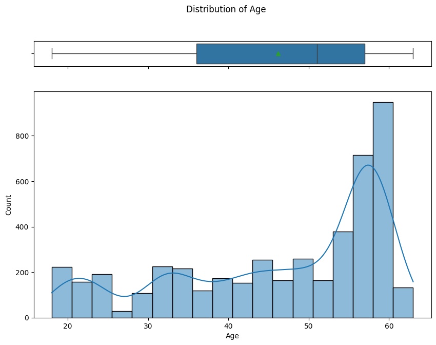

```python
hist_box_plot(df, 'age')
```

The distribution is left-skewed.

- We see that most people in the dataset are older than 50 and probably retired. This means that they probably have more time to take these courses.
- There is a gap of people around 25-28, probably because this age group is very busy with other things, like taking care of little children.
- There are no outliers

##### Website visits

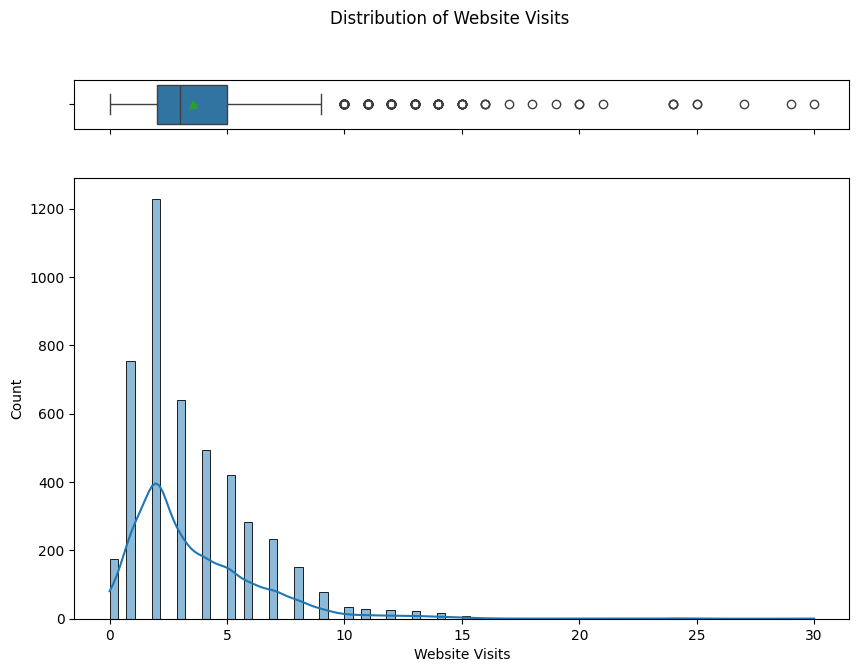

```python
hist_box_plot(df, 'website_visits')
```

The distribution is right-skewed.

- Most people have 1 to 3 visits, with a peak at 2
- Some people have more than 10 visits (up to 30). The boxplot shows them as outliers. They are however nothing to worry about for the further analysis as there are no consistently big gaps between them. There is not need to omit or correct them.

##### Time spent on website

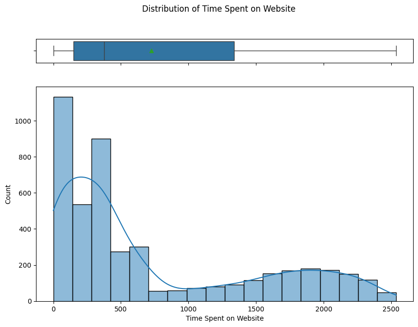

```python
hist_box_plot(df, 'time_spent_on_website')
```

The distribution of the time spent is quite interesting, with two peaks (modes):

- A first group did not spent so much time, typically below 700 minutes (?) (the unit of time is not mentioned in the description, is it minutes or seconds?), with most people even less than 400 minutes.
- A second group spent quite some more time, with a (much lower) peak around 2000 minutes.

##### Page views per visit

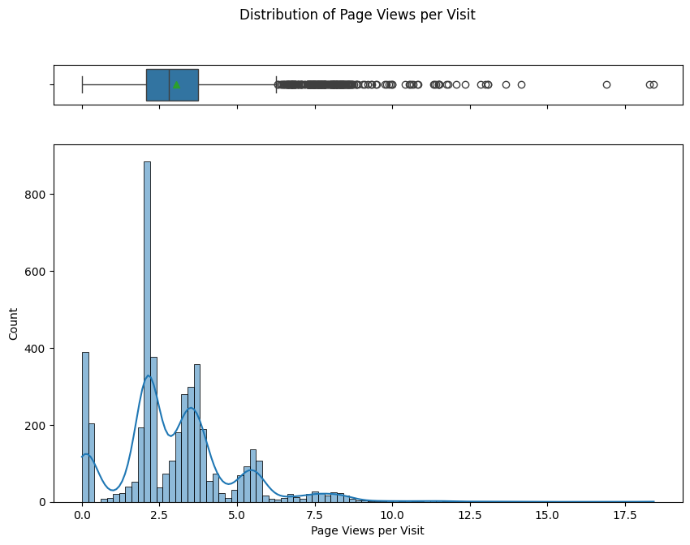

```python
hist_box_plot(df, 'page_views_per_visit')
```

This might all have something to do with the way the website is made or what the different persons are looking for, but we cannot answer on the real reason with the information we have available (it is also not relevant for this excercise).

There are quite some outliers (some even above 15), but there is no reason to believe this is faulty data. Let's however check the few data entries with more than 15 page views per visit.

```python
df[df['page_views_per_visit']>15]
```

|  | age | current_occupation | first_interaction | profile_completed | website_visits | time_spent_on_website | page_views_per_visit | last_activity | print_media_type1 | print_media_type2 | digital_media | educational_channels | referral | status | print_media_type1_num | print_media_type2_num | digital_media_num | educational_channels_num | referral_num |
| --- | --- | --- | --- | --- | --- | --- | --- | --- | --- | --- | --- | --- | --- | --- | --- | --- | --- | --- | --- |
| 4 | 23 | Student | Website | High | 4 | 600 | 16.914 | Email Activity | No | No | No | No | No | 0 | 0 | 0 | 0 | 0 | 0 |
| 32 | 58 | Professional | Mobile App | High | 12 | 1151 | 18.434 | Phone Activity | No | No | No | Yes | No | 0 | 0 | 0 | 0 | 1 | 0 |
| 268 | 57 | Professional | Mobile App | Medium | 3 | 1009 | 18.302 | Phone Activity | No | No | No | No | No | 0 | 0 | 0 | 0 | 0 | 0 |

There does not look anything abnormal for these entries. Maybe these are just people who like to discover all the pages as much as possible.

#### Univariate analysis categorical

We define some functions to vizualise this easier. We will take the function written in the previous assessment as a base again.

```python
def sorted_countplot(data, var_cat: str, label_rotation=None, annotation=True):
  """
  Creates a sorted count plot for a categorical variable in a Pandas DataFrame.

  Args:
      data (pd.DataFrame): The Pandas DataFrame containing the data.
      var_cat (str): The name of the categorical variable to plot.
      label_rotation (int, optional): The number of degrees to rotate the x-axis tick labels for better readability with many categories. Defaults to None (no rotation).
      annotation: Indicate if the percentage annotation needs to be shown or not.

  Returns:
      None. This function creates a count plot and displays it using plt.show().
  """
  # First set the correct order the data needs to be plotted
  # Get a list of the unique categorical variables
  lst = data[var_cat].unique()

  # We will first show the non-numeric data (starting with the highest occurance)
  non_numeric_elements = []
  # Then we will show the numeric (integer) elements (in numerical order)
  numeric_elements = []

  # We check for each variable if it can be recognized as an integer or not
  for item in lst:
    try:
      numeric_elements.append(int(item))
    except:
      non_numeric_elements.append(item)

  # Sort the numerical items (ascending)
  numeric_elements.sort()
  # Keep only the categorical data and order them
  data_categorical = data[data[var_cat].isin(non_numeric_elements)]
  non_numeric_elements = data_categorical[var_cat].value_counts().index.tolist()
  # This is the final order to plot
  order_categories = non_numeric_elements + numeric_elements

  # Plot the data in the order we made
  ax = sns.countplot(x =data[var_cat], data=data, order=order_categories, palette='Set2')
  # Add the titles and labels
  plt.title(f'Distribution of {variable_name(var_cat)}')
  plt.xlabel(f'{variable_name(var_cat)}')
  # Optionally rotate the x-axis tick labels
  if label_rotation is not None:
      plt.setp(ax.get_xticklabels(), rotation=label_rotation)

  # Define the annotation and add it to the plot
  if annotation == True:
    # Set ylim so the annotation is for sure in the graph
    # Set y-axis limit to 1.2 times the maximum count
    max_count = data[var_cat].value_counts().max()
    plt.ylim(0, 1.2 * max_count)


    # Total amount of data
    tot_count = data[var_cat].value_counts().sum()

    # Add a percentage annotation to the plot
    for p in ax.patches:
        x=p.get_bbox().get_points()[:,0]
        y=p.get_bbox().get_points()[1,1]
        if label_rotation is not None:
          ax.annotate('{:.1f}%'.format(100.*y/tot_count), (x.mean(), y+10),
                ha='center', va='bottom', rotation=label_rotation)
        else:
          ax.annotate('{:.1f}%'.format(100.*y/tot_count), (x.mean(), y+10),
                ha='center', va='bottom')

  plt.show()
```

##### Current occupation

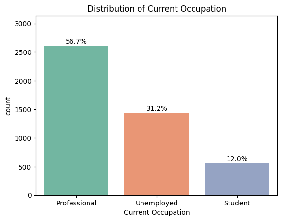

```python
sorted_countplot(df, 'current_occupation')
```

Observations:

- More than half of the people are a professional
- 30% is unemployed
- The remaining 12% is student

##### First interaction

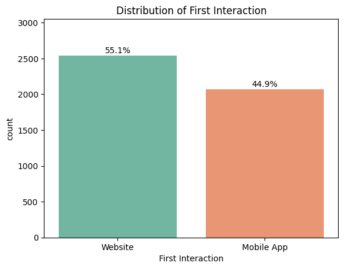

```python
sorted_countplot(df, 'first_interaction')
```

The first interaction is almost 50-50, with a small advantage for the website (55%).

##### Profile completed

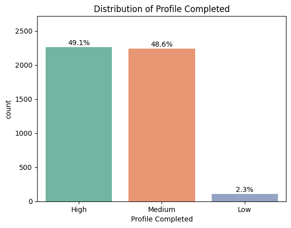

```python
sorted_countplot(df, 'profile_completed')
```

Observations:

- Half of the people filled in their profile almost completely (>75%)
- The remaining other half filled it in partly
- Only a very low percentage or 2.3% has a low filled profile

Note that for the analysis we could decide to convert this variable into a number (e.g. 1-3) indicating the level of profile completion. As we are however going to make Decision Tree and Random Forest models, this does not really change a lot on how they will model the data.

##### Last Activity

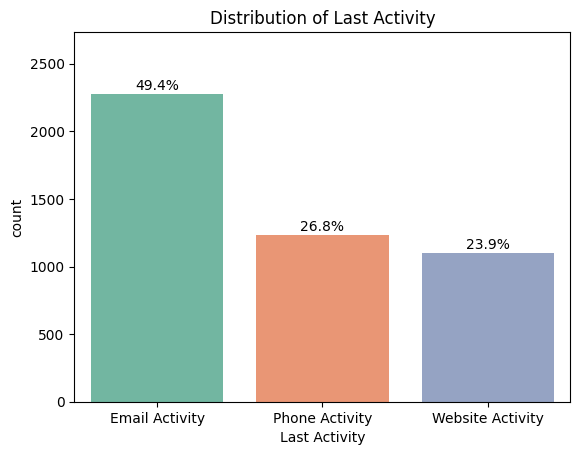

```python
sorted_countplot(df, 'last_activity')
```

Observations:

- About half of the last activities was over e-mail
- The remaining two types (phone and website) contributed both to about a quarter of the total amount of interactions

##### Newspaper advertissement

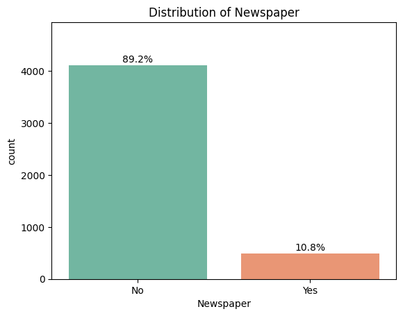

```python
sorted_countplot(df, 'print_media_type1')
```

Only 10.8% saw the newspaper add.

##### Magazine advertissement

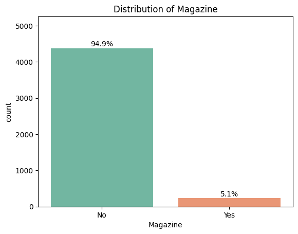

```python
sorted_countplot(df, 'print_media_type2')
```

Only 5.1% saw the magazine add.

##### Digital platform

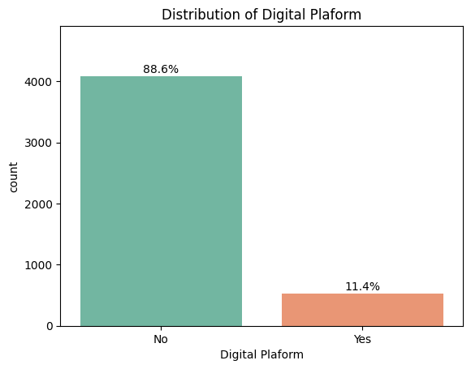

```python
sorted_countplot(df, 'digital_media')
```

Only 11.4% saw the add on the digital platforms.

##### Educational channels

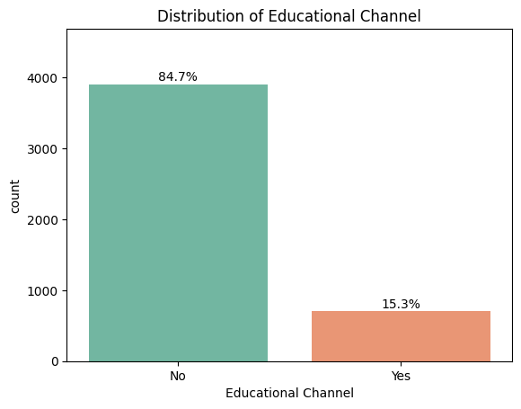

```python
sorted_countplot(df, 'educational_channels')
```

Only 15.3% saw the add on the educational channels. This is however the highest percentage of all adds that were placed.

##### Referral

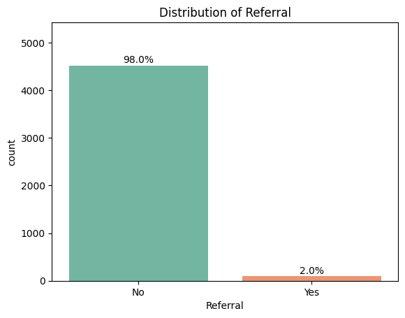

```python
sorted_countplot(df, 'referral')
```

Only 2% of the people were contacted after a referral. This is a very small percentage. As we will see later in the bivariate analysis, these people have a high lead conversion rate.

##### Status

The most important parameter. We want to understand how all other features influence this one.

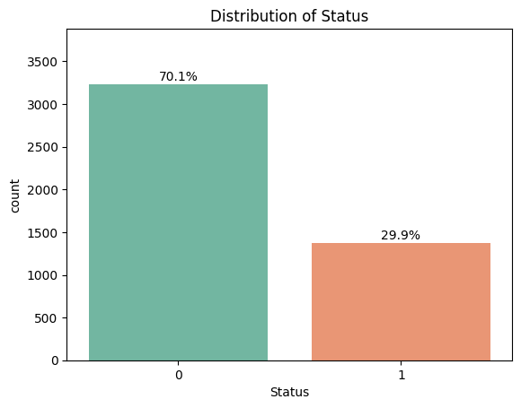

```python
sorted_countplot(df, 'status')
```

The conversion to paid customers is not balanced. Only 30% of all people are buying customers already.

#### Bi-variate analysis numerical

To check the correlation between the numerical variables, the easiest way is to start with a correlation heatmap (similar to the previous assessment). Here our numerical versions of the flag columns will come in handy.

```python
def corr_heatmap(df):
  # Check for correlation among numerical variables
  variables_list = ['age',	'website_visits',	'time_spent_on_website',	'page_views_per_visit',	'print_media_type1_num',	'print_media_type2_num',	'digital_media_num',	'educational_channels_num',	'referral_num',	'status']
  corr_matrix = df[variables_list].corr()

  # Plot the heatmap
  sns.heatmap(corr_matrix,
              cmap = 'coolwarm',
              fmt = ".2f",
              annot = True,
              xticklabels = corr_matrix.columns,
              yticklabels = corr_matrix.columns,
              linewidth=.5)

  # add title to heatmap
  plt.title('Correlation heatmap')
```

Show the heatmap:

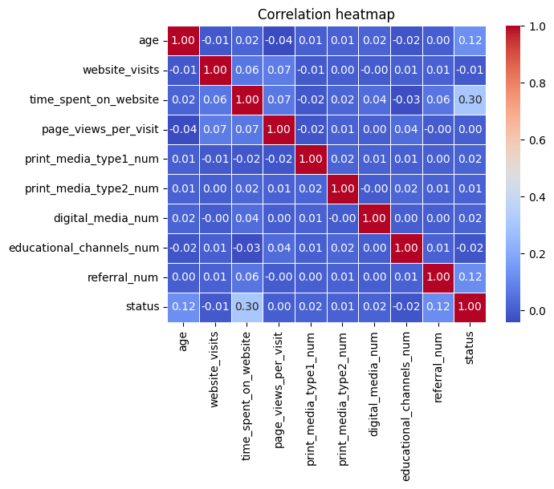

```python
corr_heatmap(df)
```

Observations:

- We generally do not see a lot of strong correlations.
- 'website_visits', 'time_spent_on_website' and 'page_views_per_visit' have logically (some weak) correlation, but it is not that strong.
- We see a slight correlation between the 'time spent on the website' and the 'status'. This makes sense, as someone who is more interested might spend more time on the website.
- We see even weaker correlations between 'age'/'referral' and the 'status'. This also makes sense, as a referral would mean the person already discussed it before with someone and is interested. The correlation with age might indicate that older people have more time and want to follow the courses.

#### Drop dummy numerical flag columns again

For the further analysis and building the model, we will use the object columns and not the dummy numerical ones

```python
df = df.drop(['print_media_type1_num', 'print_media_type2_num', 'digital_media_num', 'educational_channels_num', 'referral_num'], axis = 1)
```

#### Bi-variate analysis categorical

For the bi-variate analysis in function of the status, the categorical predictors 'Current Occupation', 'First Interaction', 'Profile Completed' and 'Last Activity' still need to be looked at. In order to do this, the easiest method is to make stacked bar plots comparing the conversion rate to paid customers for the different categories. To do this a new stacked barplot function is first made, based on the one of the previous assessment.

```python
def stacked_bar_plot(df, to_predict, influencing_factor):
  """
  Creates a stacked barplot to visualize the distribution of a variable with limited discrete options across categories in a Pandas DataFrame.

  Args:
      df (pd.DataFrame): The Pandas DataFrame containing the data.
      to_predict (str): The name of the categorical variable to group the data by.
      influencing_factor (str): The name of the categorical variable with variable with limited discrete options.

  Returns:
      None. This function creates a stacked barplot and displays it using plt.show().
  """
  # Group by category and count occurrences of each score
  grouped = df.groupby([influencing_factor, to_predict]).size().unstack(fill_value=0)

  # Calculate the row-wise sum
  row_sums = grouped.sum(axis=1)

  # Divide each element by the row sum and multiply by 100 to get the percentage
  df_normalized = grouped.div(row_sums, axis=0)*100

  # Plot it in a stacked bar plot
  df_normalized.plot(kind='bar', stacked=True)
  plt.gca().set_ylabel("%")

  # Add the ylabel
  plt.xlabel(variable_name(influencing_factor))

  # Add title
  plt.title(f'Distribution of the {variable_name(influencing_factor)} for {variable_name(to_predict)}')

  plt.show()

  return
```

##### Current Occupation

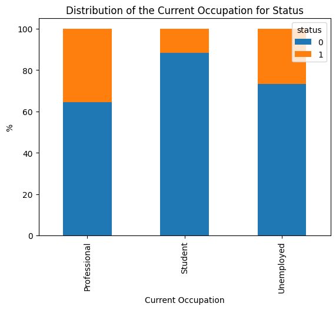

```python
stacked_bar_plot(df, 'status', 'current_occupation')
```

Observations:

- We see a big difference in the conversion to paid customers for especially students. Because there are not so financially able to pay for the courses, only a low percentage of them takes the program.
- At the other hand, we see the percentage of professionals taken the program to be higher. This is probably because they can afford it or that they need/want it for further steps in their carreer.

This answers one of the questions posed in the beginning. So yes, the occupation has a big impact on the fact that it could be a paying customer or not.

It could be interesting to look once at the age distribution for each of the different occupations. For clarity, we will combine ages in age groups (<30, 30-40, 40-50, 50+). This will be done using a new function:

```python
def categorize_age(df):
  """
  Categorizes ages in a DataFrame into age groups (<30, 30-40, 40-50, 50+).

  Args:
    df: The pandas DataFrame containing the 'age' column.

  Returns:
    The DataFrame with a new 'age_group' column containing the categorized ages.
  """
  df_age = df.copy()
  bins = [0, 30, 40, 50, float('inf')]  # Define age bins
  labels = ['<30', '30-40', '40-50', '50+']  # Define labels for each bin

  df_age['age_group'] = pd.cut(df_age['age'], bins=bins, labels=labels, right=False)
  return df_age
```

The dataframe with the age groups is then:

```python
df_with_age_groups = categorize_age(df)
```

The same bar plot function helps us now to visualize the age distribution for the different occupation categories:

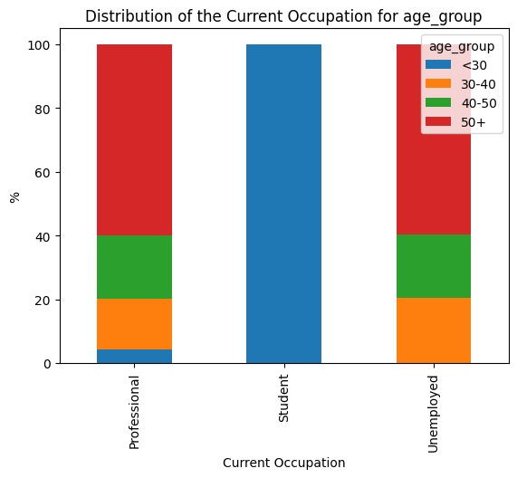

```python
stacked_bar_plot(df_with_age_groups, 'age_group', 'current_occupation')
```

We see a big correlation between the current occupation on the age. This is kind of predictable, given the fact that most students are younger than 30 and professionals are typically older. As students are less likely to become a paying customer, it might make sense to only use one of the two columns (age or occupation), as they are both containing very similar data. It might be an interesting excercise to check this once. In the scope of this excercise we will however keep all the data, to be as accurate as possible.

##### First interaction

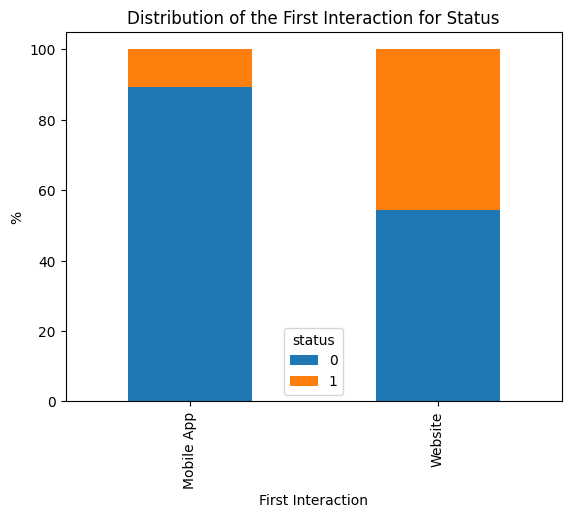

```python
stacked_bar_plot(df, 'status', 'first_interaction')
```

The conversion for users using the website first is a lot higher than when they use the mobile app.

This answers one of the questions posed in the beginning. So yes, the type of first interaction has a big impact on the fact that it could be a paying customer or not.

##### Profile Completed

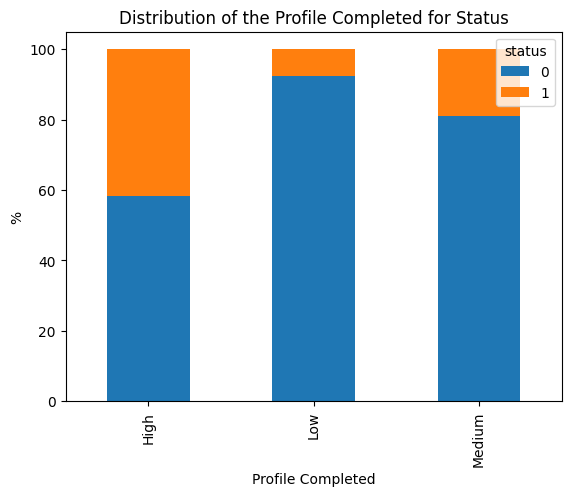

```python
stacked_bar_plot(df, 'status', 'profile_completed')
```

Observations:

- As expected, the chance of conversion rate for people who filled in their profile the most is the highest. They show most interest.
- For the lowest fill rate the interest is also lowest.

This answers one of the questions posed in the beginning. So yes, a profile that is filled better means as well that the person is more likely to become a paying customer.

##### Last Activity

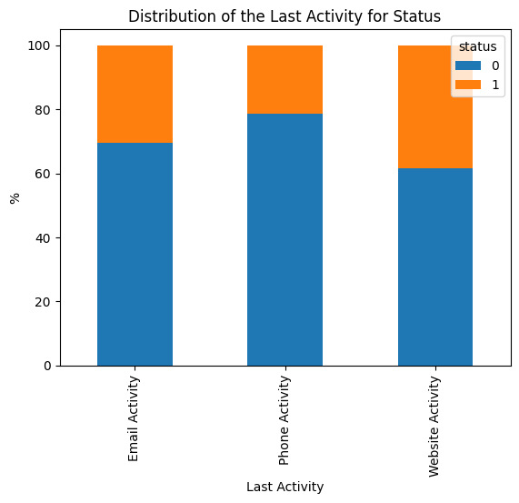

```python
stacked_bar_plot(df, 'status', 'last_activity')
```

Observations:

- The conversion rate for website as last activity is the highest
- The conversion rate for phone as last activity is the lowest

##### Others

In the bivariate analysis of the numerical features, we used dummy variables which showed us that the impact of e.g. 'print_media_type1' was not present on the lead conversion status. A stacked barplot can confirm this once again for the categorical version of this feature:

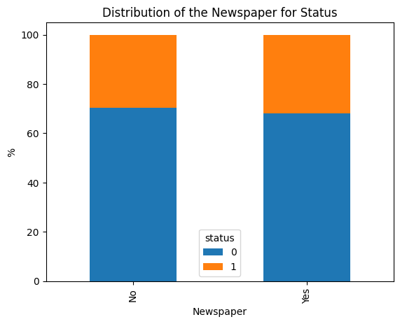

```python
stacked_bar_plot(df, 'status', 'print_media_type1')
```

As expected, we do not see any big influence on the conversion rate based on the 'print_media_type1'. This confirms what was seen in the heatmap earlier. The same is true for the 'print_media_type2', 'digital_media' and 'educational_channels'.

The same heatmap showed however an influence of a referral. The stacked barplot confirms this again:

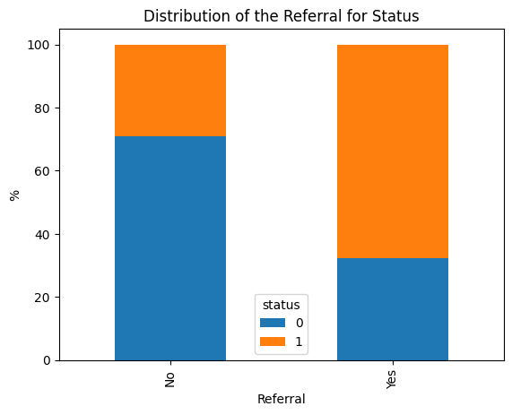

```python
stacked_bar_plot(df, 'status', 'referral')
```

We can expect a big impact of a referral on the final conversion rate. Keep however in mind that a referral was only present in 2% of the total cases.

This immediately answers the last remaining question posed above: the channels that has the biggest impact on the lead conversion rate is by far the 'referral' one.

Note that we could also check the influence between different types of advertissements (like here below between digital media and educational channels). No clear correlations are however seen when that is done for all these types. One example (between 'educational channels' and 'digital media) is given below:

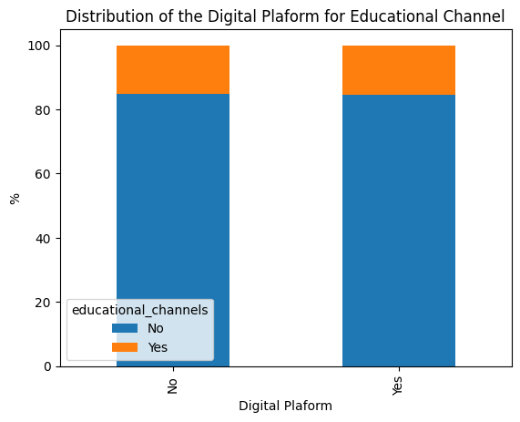

```python
stacked_bar_plot(df, 'educational_channels', 'digital_media')
```

## Building a Decision Tree model

We want to model a prediction for the which leads are likely to be converted to paying customers. In order to build a model, we need to perform the following steps:

1. Analyze the data, clean if needed, impute missing data and eliminate potential outliers. - This has been done in the previous part.
2. Perform a bi-variate analysis to see which parameters impact which other ones. Especially with a focus on the 'status' here, as this is the target of the prediction. - This has been done in the previous part.
3. When the model needs to be build, we need to further prepare the data by * removing unnecessary columns which will not have any impact on the conversion data predicted by the model (e.g. ID numbers) * split the data in the dependent (target) and independent variables * making dummy variables for the independent categorical variables * splitting the data in test and train data sets.
4. Make sure we have a measure to rate the performance of the built models.

The steps in point 3 and 4 will now be addressed.

### 3 - Preparation

a) Removing the ID column. This was already done earlier.

b) Splitting the data in the dependent (target y) and independent variables (X):

```python
y = df['status']
X = df.drop(["status"], axis=1)
```

We print the independent variables once to see if everything looks correct:

```python
X.head()
```

|  | age | current_occupation | first_interaction | profile_completed | website_visits | time_spent_on_website | page_views_per_visit | last_activity | print_media_type1 | print_media_type2 | digital_media | educational_channels | referral |
| --- | --- | --- | --- | --- | --- | --- | --- | --- | --- | --- | --- | --- | --- |
| 0 | 57 | Unemployed | Website | High | 7 | 1639 | 1.861 | Website Activity | Yes | No | Yes | No | No |
| 1 | 56 | Professional | Mobile App | Medium | 2 | 83 | 0.320 | Website Activity | No | No | No | Yes | No |
| 2 | 52 | Professional | Website | Medium | 3 | 330 | 0.074 | Website Activity | No | No | Yes | No | No |
| 3 | 53 | Unemployed | Website | High | 4 | 464 | 2.057 | Website Activity | No | No | No | No | No |
| 4 | 23 | Student | Website | High | 4 | 600 | 16.914 | Email Activity | No | No | No | No | No |

c) We create the dummy columns for the categorical independent variables:

```python
# list of the dummy columns
dummy_columns=['current_occupation', 'first_interaction', 'profile_completed', 'last_activity', 'print_media_type1',	'print_media_type2',	'digital_media',	'educational_channels',	'referral']
```

We make the dummy columns and drop the initial categorical ones:

```python
X=pd.get_dummies(X, columns=dummy_columns, drop_first=True)
```

Another check of 'X' to see if all is ok:

```python
X.head()
```

|  | age | website_visits | time_spent_on_website | page_views_per_visit | current_occupation_Student | current_occupation_Unemployed | first_interaction_Website | profile_completed_Low | profile_completed_Medium | last_activity_Phone Activity | last_activity_Website Activity | print_media_type1_Yes | print_media_type2_Yes | digital_media_Yes | educational_channels_Yes | referral_Yes |
| --- | --- | --- | --- | --- | --- | --- | --- | --- | --- | --- | --- | --- | --- | --- | --- | --- |
| 0 | 57 | 7 | 1639 | 1.861 | False | True | True | False | False | False | True | True | False | True | False | False |
| 1 | 56 | 2 | 83 | 0.320 | False | False | False | False | True | False | True | False | False | False | True | False |
| 2 | 52 | 3 | 330 | 0.074 | False | False | True | False | True | False | True | False | False | True | False | False |
| 3 | 53 | 4 | 464 | 2.057 | False | True | True | False | False | False | True | False | False | False | False | False |
| 4 | 23 | 4 | 600 | 16.914 | True | False | True | False | False | False | False | False | False | False | False | False |

We print the info on this dataframe as well, to see if that is ok:

```python
X.info()
```

```
<class 'pandas.core.frame.DataFrame'>
RangeIndex: 4612 entries, 0 to 4611
Data columns (total 16 columns):
 #   Column                          Non-Null Count  Dtype
---  ------                          --------------  -----
 0   age                             4612 non-null   int64
 1   website_visits                  4612 non-null   int64
 2   time_spent_on_website           4612 non-null   int64
 3   page_views_per_visit            4612 non-null   float64
 4   current_occupation_Student      4612 non-null   bool
 5   current_occupation_Unemployed   4612 non-null   bool
 6   first_interaction_Website       4612 non-null   bool
 7   profile_completed_Low           4612 non-null   bool
 8   profile_completed_Medium        4612 non-null   bool
 9   last_activity_Phone Activity    4612 non-null   bool
 10  last_activity_Website Activity  4612 non-null   bool
 11  print_media_type1_Yes           4612 non-null   bool
 12  print_media_type2_Yes           4612 non-null   bool
 13  digital_media_Yes               4612 non-null   bool
 14  educational_channels_Yes        4612 non-null   bool
 15  referral_Yes                    4612 non-null   bool
dtypes: bool(12), float64(1), int64(3)
memory usage: 198.3 KB
```

We have 16 columns remaining. No categorical ones, but just dummy boolean columns and also our temporary numerical columns are not present anymore (e.g. 'print_media_type1_num' from earlier).

d) We split the data in test and train data sets (70-30 ratio). We use the stratify setting to make sure the frequencies between lead conversions are similar between the test and train datasets. I will use random state 1 for repeatability (could be 42 as well).

```python
X_train, X_test, y_train, y_test = train_test_split(X,y,test_size=0.30,random_state=1,stratify=y)
```

We should still check if it all makes sense now:

```python
print("The dataframe shapes are as follows:")
print(f"X_train: {X_train.shape}")
print(f"X_test: {X_test.shape}")
print(f"y_train: {y_train.shape}")
print(f"y_test: {y_test.shape}")
```

```
The dataframe shapes are as follows:
X_train: (3228, 16)
X_test: (1384, 16)
y_train: (3228,)
y_test: (1384,)
```

30% is test dataset and 70% train. Let's also check if the 'stratify function did its work:

```python
print(y_train.sum()/y_train.count())
print(y_test.sum()/y_test.count())
```

```
0.298636926889715
0.2984104046242775
```

The ratio of lead conversions is for both the train and test dataset around 0.298. That is what we wanted.

### 4 - Model evaluation

As usual, we can build many different models. But we need to ask ourselves the question: what is the most important factor for this model?

A model can predict **false positives**:

The model predicts that a lead will convert, but eventually it will not. When this happens, we will lose resources on a lead that would not convert anyway. This is not desired.

A model can predict **false negatives**:

The model predicts that a lead will not convert, but it would have done it if treated in the correct way. When this happens, we will lose income and a new paying customer. This is also not desired.

Logically, the loss of a potential income (false negatives) is worse than wasting temporarily some resources. Therefor, we will try to reduce the amount of false negatives in our models. This means that we should aim at higher recall value.

A function that contains the classification report, shows the confusion matrix (all part of sklearn.metrics) will help to better judge the performance of the models that we build:

```python
# Function that decribes the model metrics scores
def metrics_score(actual, predicted):
  """
  Calculates and displays classification model performance metrics.

  Args:
      actual (array-like): Ground truth labels for the classification task.
      predicted (array-like): Predicted labels by the classification model.
  """

  # Classification report
  print("Classification Report:\n")
  print(classification_report(actual, predicted))

  # Confusion matrix
  cm = confusion_matrix(actual, predicted)
  plt.figure(figsize=(7,6))

  # Heatmap with annotations
  sns.heatmap(cm, annot=True,  fmt='.0f')
  plt.title('Confusion Matrix')
  plt.ylabel('Actual')
  plt.xlabel('Predicted')

  plt.show()
```

### Building the Decision Tree

Now, building the decision tree goes pretty fast with the available libraries:

```python
# We use the decision tree classifier to fit on the training data set. We add the class weights (which we just calculated), as it is unbalanced.
model_dt = DecisionTreeClassifier(random_state=1, class_weight = {0: 0.298, 1: 0.702})
model_dt.fit(X_train, y_train)
```

```
DecisionTreeClassifier(class_weight={0: 0.298, 1: 0.702}, random_state=1)
```

But of course the performances needs to be evaluated:

```
Classification Report:

              precision    recall  f1-score   support

           0       1.00      1.00      1.00      2264
           1       1.00      1.00      1.00       964

    accuracy                           1.00      3228
   macro avg       1.00      1.00      1.00      3228
weighted avg       1.00      1.00      1.00      3228
```

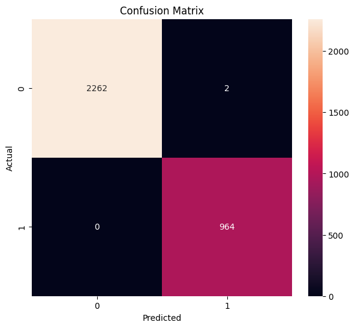

```python
# Evaluate performance on the training dataset
pred_train_dt = model_dt.predict(X_train)
metrics_score(y_train, pred_train_dt)
```

The recall and precision are both 1 in this model, which is of course very suspicious and will probably mean that we are overfitting and the we need to prune the tree. We can confirm this when we compare with the test dataset performance:

```
Classification Report:

              precision    recall  f1-score   support

           0       0.84      0.86      0.85       971
           1       0.66      0.63      0.64       413

    accuracy                           0.79      1384
   macro avg       0.75      0.75      0.75      1384
weighted avg       0.79      0.79      0.79      1384
```

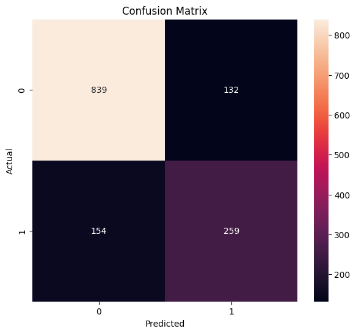

```python
# Evaluate performance on the test dataset
pred_test_dt = model_dt.predict(X_test)
metrics_score(y_test, pred_test_dt)
```

The model scores a lot worse on the test dataset, compared to the training dataset. This indicates overfitting. We will need to take action to improve the model's performance.

## Do we need to prune the tree?

As written at the end of the previous section, the performance of our model on the newly seen test dataset is a lot worse than on the training dataset. As happens often with decision trees, this means we are overfitting the model. We will need to tune the tree to reduce overfitting and better balance it for new unseen datasets.

We can play with different parameters e.g.

- maximum depth
- criteria
- minimum samples split
- minimum samples leaf
- maximum features
- minimum weight fraction leaf

to tune the tree.

The search for the best combination can be done with a grid search, a random search, a Bayesian optimization,...

We will use GridSearch.

#### Grid search

```python
# Choose the type of classifier, we add the class weights, as it is unbalanced. Without these class weights, the results are worse for what we want to model for.
model_dt_tuned = DecisionTreeClassifier(random_state = 1, class_weight = {0: 0.298, 1: 0.702})

# Grid of parameters to choose from
parameters = {'max_depth': np.arange(2, 8),
              'criterion': ['gini', 'entropy'],
              #'min_samples_leaf': [5, 10, 20, 25], # Did not have a big impact, omitted for further calculations and trials to speed up
              #'min_samples_split': [5, 10, 20, 25], # Did not have a big impact, omitted for further calculations and trials to speed up
              'max_features': [0.5, 0.7, 0.8, 0.9, 'auto', 'sqrt','log2']
             }
```

As the recall score for converted leads (y=1) needs to be as high as possible, we can specify this more clearly with make scoring when we run the grid search. We could also build another scorer ourselves, but that does not look necessary here with the 'recall' feature.

```python
# Run the search
grid_obj = GridSearchCV(model_dt_tuned, parameters, cv=5,scoring='recall',n_jobs=-1)
grid_obj = grid_obj.fit(X_train, y_train)

# Set the classifier to the best combination of parameters
model_dt_tuned = grid_obj.best_estimator_

# Fit the best algorithm to the data.
model_dt_tuned.fit(X_train, y_train)
```

```
DecisionTreeClassifier(class_weight={0: 0.298, 1: 0.702}, max_depth=4,
                       max_features='sqrt', random_state=1)
```

```
Classification Report:

              precision    recall  f1-score   support

           0       0.97      0.63      0.77      2264
           1       0.53      0.96      0.68       964

    accuracy                           0.73      3228
   macro avg       0.75      0.80      0.72      3228
weighted avg       0.84      0.73      0.74      3228
```

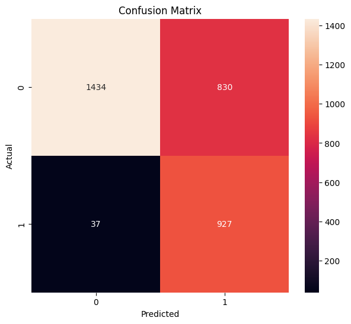

```python
# Checking performance on the training dataset
dt_pred_tuned_train = model_dt_tuned.predict(X_train)
metrics_score(y_train,dt_pred_tuned_train)
```

```
Classification Report:

              precision    recall  f1-score   support

           0       0.97      0.61      0.75       971
           1       0.51      0.96      0.67       413

    accuracy                           0.72      1384
   macro avg       0.74      0.79      0.71      1384
weighted avg       0.84      0.72      0.73      1384
```

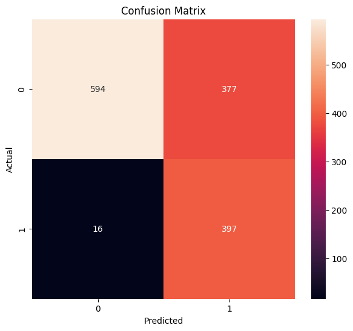

```python
# Checking performance on the test dataset
dt_pred_tuned_test = model_dt_tuned.predict(X_test)
metrics_score(y_test,dt_pred_tuned_test)
```

Conclusions:

- Many different searches and combinations (which I did not keep here in the code), showed that the tuning parameters 'max_depth', 'criterion' and 'max_features' had the biggest impact on the result. A parameter like 'min_samples_leaf' did not change so much to the outcome, neither did changing between 'entropy' or 'gini' as criterion.
- We see that for a maximum depth of of 4 and using the 'sqrt' (only the square root of the total number of features for each split) we achieve a model with a recall of 96% for the target of y=1. This is a high number, exactly what we aimed for.
- The precision score of only about 0.53 for y=1 is not that good, so often resources will be spilled in trying to convince a dead-end lead. However, we decided initially that this is a lot less worse than losing the potential income of a lead that would have converted. Precision and recall are typically a trade-off. If we aim for a better recall, it will come with a cost for the precision.
- The results for the test and train set are very similar, this indicates that we do not really have overfitting anymore.

#### Tree visualization and feature importance

In order to understand the model a bit more, it can be visualized and we can check which of the different features has in fact the most impact.

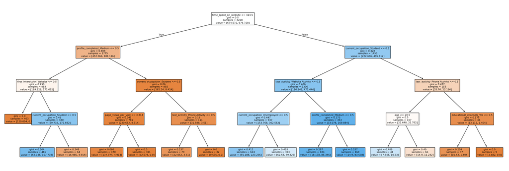

```python
# Plot the tree till maximum depth of 4
feature_names = list(X_train.columns)
plt.figure(figsize=(30, 10))
tree.plot_tree(model_dt_tuned, max_depth=4, feature_names=feature_names, filled=True, fontsize=8, node_ids=False, class_names=None)

plt.show()
```

Blue in the plot represents conversion of a lead to a paying customer. Orange indicates leads that will most likely not convert.

What the plot learns us is that the time spent on the website is considered the first deciding factor. Then they look at the profile completion and the occupation. In the bivariate analysis we saw exactly those parameters are having an impact on the final conversion rate. As referral was only present in 2% of all cases, it is understandable it is not prevailing in the tree.

When looking at the feature importance, this is largely confirmed again. The following is the list of the different features in our model and their relative importance:

```python
print(round(pd.DataFrame(model_dt_tuned.feature_importances_, columns = ["importance [%]"], index = X_train.columns).sort_values(by = 'importance [%]', ascending = False)*100,2))
```

```
                                importance [%]
time_spent_on_website                    37.46
first_interaction_Website                27.79
profile_completed_Medium                 20.97
current_occupation_Student                7.90
last_activity_Website Activity            2.90
current_occupation_Unemployed             1.52
last_activity_Phone Activity              1.24
age                                       0.16
page_views_per_visit                      0.05
educational_channels_Yes                  0.02
website_visits                            0.00
profile_completed_Low                     0.00
print_media_type1_Yes                     0.00
print_media_type2_Yes                     0.00
digital_media_Yes                         0.00
referral_Yes                              0.00
```

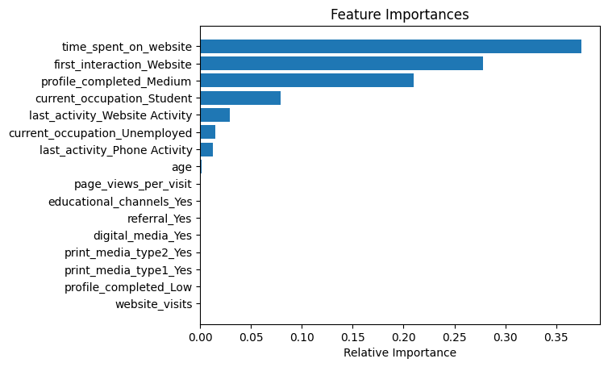

```python
# Feature importances
importances = model_dt_tuned.feature_importances_
indices = np.argsort(importances)

plt.title("Feature Importances")
plt.barh(range(len(indices)), importances[indices],align="center")
plt.yticks(range(len(indices)), [feature_names[i] for i in indices])
plt.xlabel("Relative Importance")
plt.show()
```

We can see that the current occupation is important, but the age is not so. However, we know there is a link between them, as we discussed before. So an alternative model might have swapped the influences of these two (see also the second decision tree model we build in the following).